# week_06_histograms_continued

## CMPINF 2130 Summer 2021 - Week 06

## Import Modules

```python
import numpy as np
import pandas as pd
import matplotlib.pyplot as plt

import seaborn as sns
```

## Load mpg data

The github repo: https://github.com/vincentarelbundock/Rdatasets/blob/master/csv/ggplot2/mpg.csv

But remember to read from the "raw" page.

```python
url_mpg = 'https://raw.githubusercontent.com/vincentarelbundock/Rdatasets/master/csv/ggplot2/mpg.csv'

mpg = pd.read_csv(url_mpg, index_col=0)
```

```python
mpg.info()
```

```
<class 'pandas.core.frame.DataFrame'>
Int64Index: 234 entries, 1 to 234
Data columns (total 11 columns):
 #   Column        Non-Null Count  Dtype
---  ------        --------------  -----
 0   manufacturer  234 non-null    object
 1   model         234 non-null    object
 2   displ         234 non-null    float64
 3   year          234 non-null    int64
 4   cyl           234 non-null    int64
 5   trans         234 non-null    object
 6   drv           234 non-null    object
 7   cty           234 non-null    int64
 8   hwy           234 non-null    int64
 9   fl            234 non-null    object
 10  class         234 non-null    object
dtypes: float64(1), int64(4), object(6)
memory usage: 21.9+ KB
```

To show the number of unique values for every column, we use the `.nunique()` method.

```python
mpg.nunique()
```

```
manufacturer    15
model           38
displ           35
year             2
cyl              4
trans           10
drv              3
cty             21
hwy             27
fl               5
class            7
dtype: int64
```

How do we check the number of missing values?

```python
mpg.isna().sum()
```

```
manufacturer    0
model           0
displ           0
year            0
cyl             0
trans           0
drv             0
cty             0
hwy             0
fl              0
class           0
dtype: int64
```

We can also select only the numeric or **number** data type columns.

```python
mpg.select_dtypes('number')
```

|  | displ | year | cyl | cty | hwy |
| --- | --- | --- | --- | --- | --- |
| 1 | 1.8 | 1999 | 4 | 18 | 29 |
| 2 | 1.8 | 1999 | 4 | 21 | 29 |
| 3 | 2.0 | 2008 | 4 | 20 | 31 |
| 4 | 2.0 | 2008 | 4 | 21 | 30 |
| 5 | 2.8 | 1999 | 6 | 16 | 26 |
| ... | ... | ... | ... | ... | ... |
| 230 | 2.0 | 2008 | 4 | 19 | 28 |
| 231 | 2.0 | 2008 | 4 | 21 | 29 |
| 232 | 2.8 | 1999 | 6 | 16 | 26 |
| 233 | 2.8 | 1999 | 6 | 18 | 26 |
| 234 | 3.6 | 2008 | 6 | 17 | 26 |

234 rows × 5 columns

To select all non-numeric columns use `'object'`.

```python
mpg.select_dtypes('object')
```

|  | manufacturer | model | trans | drv | fl | class |
| --- | --- | --- | --- | --- | --- | --- |
| 1 | audi | a4 | auto(l5) | f | p | compact |
| 2 | audi | a4 | manual(m5) | f | p | compact |
| 3 | audi | a4 | manual(m6) | f | p | compact |
| 4 | audi | a4 | auto(av) | f | p | compact |
| 5 | audi | a4 | auto(l5) | f | p | compact |
| ... | ... | ... | ... | ... | ... | ... |
| 230 | volkswagen | passat | auto(s6) | f | p | midsize |
| 231 | volkswagen | passat | manual(m6) | f | p | midsize |
| 232 | volkswagen | passat | auto(l5) | f | p | midsize |
| 233 | volkswagen | passat | manual(m5) | f | p | midsize |
| 234 | volkswagen | passat | auto(s6) | f | p | midsize |

234 rows × 6 columns

## Visualize hwy distribution

Histogram in Seaborn is created with the figure level function `sns.displot()`.

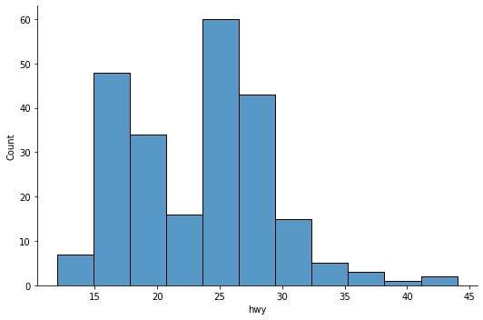

```python
sns.displot( data = mpg, x='hwy', kind='hist', aspect=1.5)

plt.show()
```

Modify the number of bins.

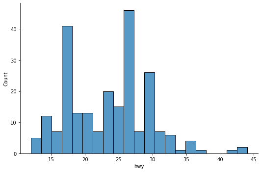

```python
sns.displot( data = mpg, x='hwy', kind='hist', aspect=1.5,
             bins = 21)

plt.show()
```

Modify the binwidth.

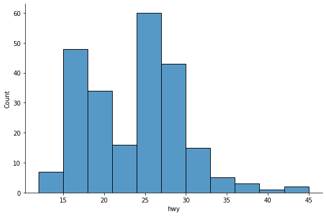

```python
sns.displot( data = mpg, x='hwy', kind='hist', aspect=1.5,
             binwidth = 3)

plt.show()
```

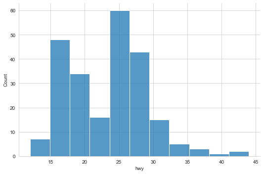

```python
sns.set_style('whitegrid')

sns.displot( data = mpg, x='hwy', kind='hist', aspect=1.5)

plt.show()
```

Can turn off the fill.

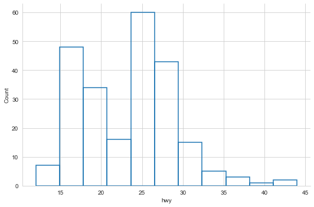

```python
sns.displot( data = mpg, x='hwy', kind='hist', aspect=1.5,
             fill=False)

plt.show()
```

We can include a rug by setting `rug = True`.

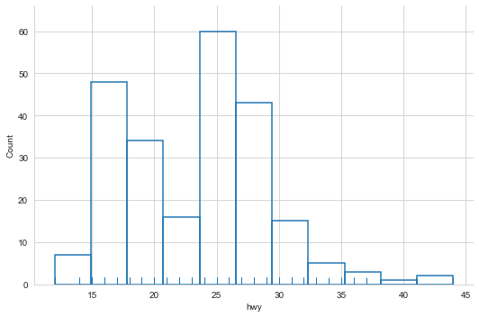

```python
sns.displot( data = mpg, x='hwy', kind='hist', aspect=1.5,
             rug = True, fill=False)

plt.show()
```

To overlay a kernel density estimate with a histogram we just set `kde = True`.

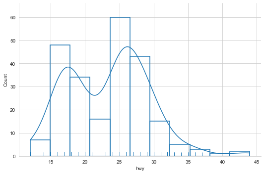

```python
sns.displot( data = mpg, x='hwy', kind='hist', aspect=1.5,
             fill=False, rug=True, kde=True)

plt.show()
```

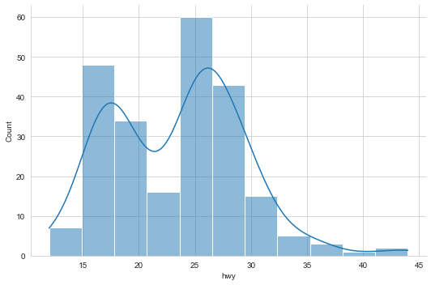

```python
sns.displot( data = mpg, x='hwy', kind='hist', aspect=1.5,
             kde=True)

plt.show()
```

The eCDF is specified with `kind = 'ecdf'`.

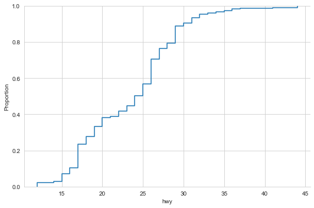

```python
sns.displot( data = mpg, x='hwy', kind='ecdf', aspect=1.5)

plt.show()
```

Compare the distribution between groups with a histogram by assigning `hue` to a categorical.

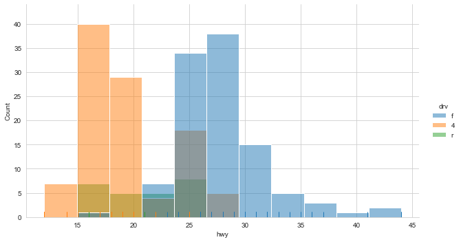

```python
sns.displot(data = mpg, x='hwy', hue = 'drv', kind='hist', rug=True,
            aspect = 1.75)

plt.show()
```

Density plot is easier to compare the distribution between the groups.

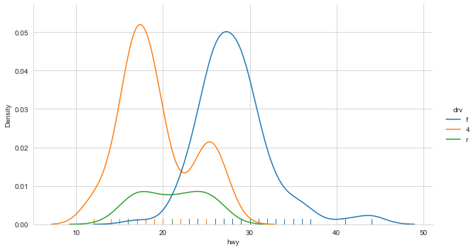

```python
sns.displot(data = mpg, x='hwy', hue='drv', kind='kde', rug=True, aspect=1.75)

plt.show()
```

The default Seaborn `.displot()` with `hue` assigned to a cateogorical is sensitive to the group sample size!!!!

Instead, we must override the default `common_norm` argument.

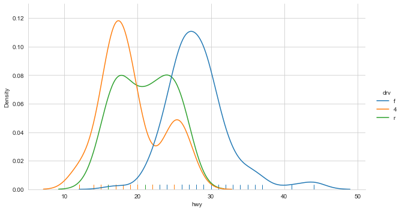

```python
sns.displot(data = mpg, x='hwy', hue='drv', kind='kde', rug=True, aspect=1.75,
            common_norm=False)

plt.show()
```

Lastly, we could use the frequency polygon.

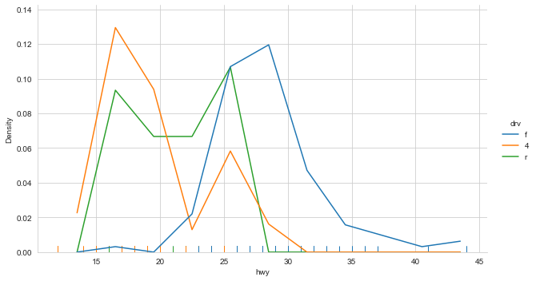

```python
sns.displot(data = mpg, x='hwy', hue='drv',
            kind='hist', element='poly', rug=True,
            stat='density',
            binwidth=3,
            aspect=1.75,
            common_norm=False,
            fill=False)

plt.show()
```

To add "layers" requires working with the axis level functions. So let's add a marginal distribution with the conditional distributions.

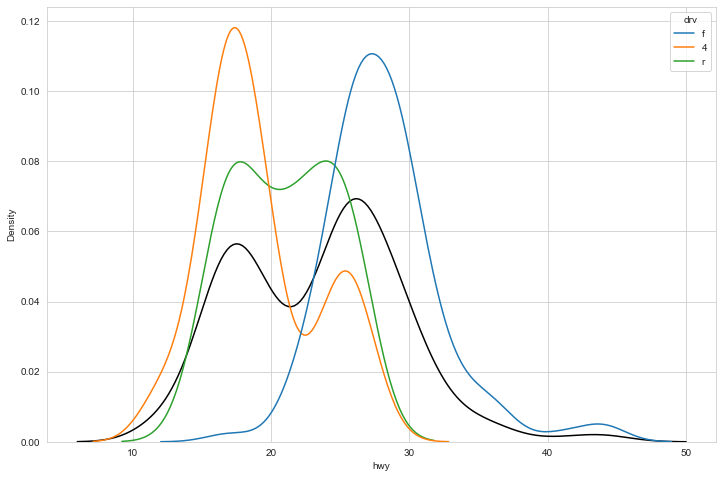

```python
fig, ax = plt.subplots(figsize=(12, 8))

sns.kdeplot(data = mpg, x='hwy', c='k', ax=ax)

sns.kdeplot(data = mpg, x='hwy', hue='drv', common_norm=False, ax=ax)

plt.show()
```

For the eCDF.

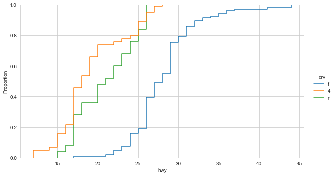

```python
sns.displot(data = mpg, x='hwy', hue='drv', kind='ecdf', aspect=1.75)

plt.show()
```

## Quantiles and Boxplots

```python
mpg.groupby(['drv']).hwy.describe()
```

| drv | count | mean | std | min | 25% | 50% | 75% | max |
| --- | --- | --- | --- | --- | --- | --- | --- | --- |
| 4 | 103.0 | 19.174757 | 4.078704 | 12.0 | 17.0 | 18.0 | 22.0 | 28.0 |
| f | 106.0 | 28.160377 | 4.206881 | 17.0 | 26.0 | 28.0 | 29.0 | 44.0 |
| r | 25.0 | 21.000000 | 3.662877 | 15.0 | 17.0 | 21.0 | 24.0 | 26.0 |

Boxplots are associated with the `sns.catplot()` figure level function.

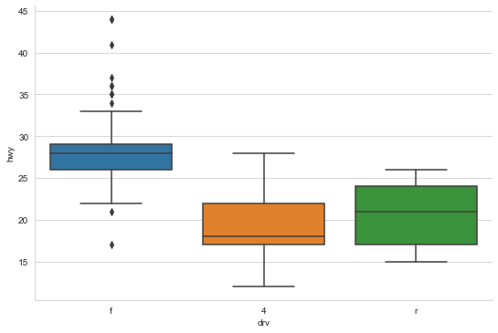

```python
sns.catplot(data = mpg, x='drv', y='hwy', kind='box', aspect=1.5)

plt.show()
```

Strip plot.

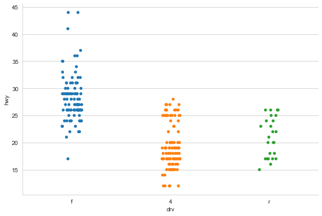

```python
sns.catplot(data = mpg, x='drv', y='hwy', kind='strip', aspect=1.5)

plt.show()
```

The beeswarm plot.

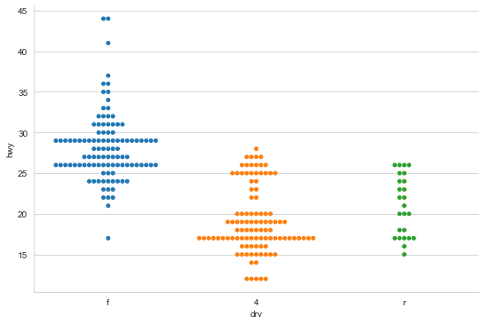

```python
sns.catplot(data = mpg, x='drv', y='hwy', kind='swarm', aspect=1.5)

plt.show()
```

bee swarm with the boxplot.

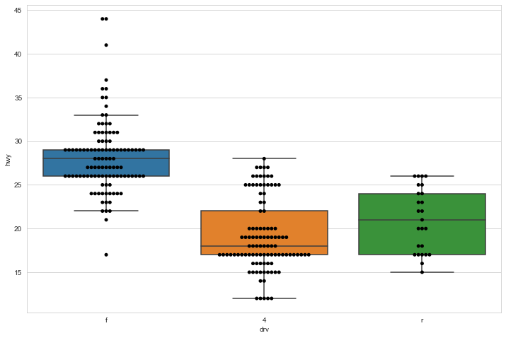

```python
fig, ax = plt.subplots(figsize=(12, 8))

sns.boxplot(data = mpg, x='drv', y='hwy', ax=ax, showfliers=False)

sns.swarmplot(data = mpg, x='drv', y='hwy', color='k', ax=ax)

plt.show()
```

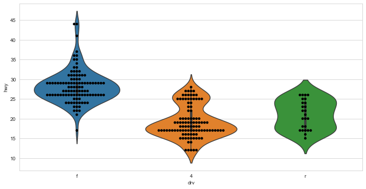

```python
fig, ax = plt.subplots(figsize = (12, 6))

sns.violinplot(data = mpg, x='drv', y='hwy', ax=ax)

sns.swarmplot(data = mpg, x='drv', y='hwy', color='k', ax=ax)

plt.show()
```